# Stat 151A Lab 12

Bryan Liu

November 9, 2018

# Generalized linear models

Suppose we have data $\{(x_1, y_1), ..., (x_n, y_n)\}$. Here, $x_n\in\mathbb{R}^p$ and $y\in \mathbb{R}$. For much of the class, we have considered modeling the data as $y_i \sim \mathcal{N}(x_i^T\beta, \sigma^2)$.

This may not always be a reasonable model. For example, the responses $y_i$ might be binary. We might then model the probability of $y_i = 1$ as $p_i = s(x_i^T\beta)$, where $s(x)$ is the sigmoid function, $s(x) = \frac{e^{x}}{1 + e^x}$. In other words, we have

$$\begin{align}
y_i \sim \text{Bernoulli}\big(p_i = s(x_i^T\beta)\big)
\end{align}$$

This is known as **logistic regression**.

Why the choice of the sigmoid function for $p_i$? In class you showed that this falls out from the exponential family paramterization of the Bernoulli distribution.

But any function that maps the reals onto the interval 0 and 1 will work. So another common function to use is the inverse cdf function of a normal distribution, $\Phi^{-1}$, and set $p_i = \Phi^{-1}(x_i^T\beta)$. This is known as **probit regression**.

The last example we shall consider is **Poisson regression**, where $y_i$ are counts (i.e., non-negative integers). Here, we model $y_i$ as
$$\begin{align}
y_i \sim \text{Poisson}(\lambda_i = \exp(x_i^T\beta))
\end{align}$$

In words, expectation of $y_i$ is $\lambda_i = \exp(x_i^T\beta)$.

Again, why the exponential function? Any map from the reals to the positive reals can be used to model the mean here. The exponential function falls out of the exponential family paramterization of the Poisson. These link functions (the exponential, and the sigmoid discussed above), are known as “canonical link functions,” canonical because they come from the exponential family paramterization.

## Example of logistic regression

We consider the `spam` dataset, [^1] where 4601 emails were collected and labeled as “spam” or “not spam” (ham). There are fifty-seven covariates collected for each email:

- Counts of forty-eight keywords (e.g.money, free) in the email, divided by the total number of words in the email .
- Counts of six characters (e.g. #, $), in the email, divided by the total number of characters in the email .
- Longest length of of uninterrupted sequences of capital letters
- Average length of uninterrupted sequences of capital letters
- Total number of capital letters

```r
# load the data
spam_data <- read.csv('./SPAM.csv')

spam_data_train <- spam_data[spam_data$testid == FALSE, ]
spam_data_train <- spam_data_train[, -2] # remove the testid column

spam_data_test <- spam_data[spam_data$testid == TRUE, ]
spam_data_test <- spam_data_test[, -2]

head(spam_data)
```

```
##   spam testid make address  all X3d  our over remove internet order mail
## 1 TRUE   TRUE 0.00    0.64 0.64   0 0.32 0.00   0.00     0.00  0.00 0.00
## 2 TRUE  FALSE 0.21    0.28 0.50   0 0.14 0.28   0.21     0.07  0.00 0.94
## 3 TRUE   TRUE 0.06    0.00 0.71   0 1.23 0.19   0.19     0.12  0.64 0.25
## 4 TRUE  FALSE 0.00    0.00 0.00   0 0.63 0.00   0.31     0.63  0.31 0.63
## 5 TRUE  FALSE 0.00    0.00 0.00   0 0.63 0.00   0.31     0.63  0.31 0.63
## 6 TRUE  FALSE 0.00    0.00 0.00   0 1.85 0.00   0.00     1.85  0.00 0.00
##   receive will people report addresses free business email  you credit
## 1    0.00 0.64   0.00   0.00      0.00 0.32     0.00  1.29 1.93   0.00
## 2    0.21 0.79   0.65   0.21      0.14 0.14     0.07  0.28 3.47   0.00
## 3    0.38 0.45   0.12   0.00      1.75 0.06     0.06  1.03 1.36   0.32
## 4    0.31 0.31   0.31   0.00      0.00 0.31     0.00  0.00 3.18   0.00
## 5    0.31 0.31   0.31   0.00      0.00 0.31     0.00  0.00 3.18   0.00
## 6    0.00 0.00   0.00   0.00      0.00 0.00     0.00  0.00 0.00   0.00
##   your font X000 money hp hpl george X650 lab labs telnet X857 data X415
```

[output cut: 27 more lines]

We fit logistic regression:

```r
logistic_model <- glm(spam ~ ., data = spam_data_train, family = binomial)
summary(logistic_model)
```

```
##
## Call:
## glm(formula = spam ~ ., family = binomial, data = spam_data_train)
##
## Deviance Residuals:
##     Min       1Q   Median       3Q      Max
## -4.4162  -0.1754   0.0000   0.0959   3.6230
##
## Coefficients:
##               Estimate Std. Error z value Pr(>|z|)
## (Intercept) -1.710e+00  1.827e-01  -9.356  < 2e-16 ***
## make        -1.754e-01  2.578e-01  -0.680 0.496312
## address     -1.428e-01  8.178e-02  -1.746 0.080860 .
## all          2.332e-01  1.555e-01   1.500 0.133705
## X3d          2.425e+00  1.891e+00   1.282 0.199690
## our          4.014e-01  1.098e-01   3.656 0.000256 ***
## over         1.068e+00  3.409e-01   3.133 0.001728 **
## remove       2.362e+00  4.216e-01   5.603 2.11e-08 ***
## internet     7.119e-01  2.269e-01   3.138 0.001700 **
## order        1.129e+00  3.988e-01   2.831 0.004646 **
## mail         9.478e-02  8.154e-02   1.162 0.245084
## receive     -3.705e-01  4.214e-01  -0.879 0.379182
## will        -1.739e-01  9.180e-02  -1.895 0.058113 .
## people      -1.571e-01  3.210e-01  -0.489 0.624511
## report       7.728e-02  2.353e-01   0.328 0.742608
## addresses    6.402e-01  7.351e-01   0.871 0.383832
## free         1.215e+00  1.898e-01   6.400 1.55e-10 ***
## business     1.356e+00  3.043e-01   4.455 8.37e-06 ***
## email        5.866e-02  1.479e-01   0.397 0.691613
## you          1.523e-01  4.262e-02   3.574 0.000352 ***
## credit       8.510e-01  6.924e-01   1.229 0.219029
## your         2.018e-01  6.547e-02   3.083 0.002053 **
## font         2.982e-01  2.433e-01   1.226 0.220249
## X000         2.101e+00  5.722e-01   3.672 0.000240 ***
## money        4.414e-01  1.996e-01   2.211 0.027045 *
## hp          -2.106e+00  3.762e-01  -5.599 2.15e-08 ***
## hpl         -3.380e-01  3.415e-01  -0.990 0.322312
## george      -2.044e+01  3.105e+00  -6.585 4.55e-11 ***
## X650        -1.253e-01  4.109e-01  -0.305 0.760381
## lab         -2.458e+00  1.715e+00  -1.433 0.151761
```

[output cut: 23 more lines]

```
## ch..4        6.716e+00  9.928e-01   6.765 1.33e-11 ***
## ch..5        2.187e+00  1.497e+00   1.460 0.144193
## crl.ave      3.688e-02  2.941e-02   1.254 0.209766
## crl.long     1.233e-02  3.619e-03   3.407 0.000656 ***
## crl.tot      5.785e-04  2.877e-04   2.011 0.044367 *
## ---
## Signif. codes:  0 '***' 0.001 '**' 0.01 '*' 0.05 '.' 0.1 ' ' 1
##
## (Dispersion parameter for binomial family taken to be 1)
##
##     Null deviance: 4119  on 3064  degrees of freedom
## Residual deviance: 1125  on 3007  degrees of freedom
## AIC: 1241
##
## Number of Fisher Scoring iterations: 13
```

Our prediction accuracy on the train set:

```r
get_predictions <- function(logistic_model, data){
  # returns binary predictions for the logistic model on given data

  # notice the type argument: this returns the probs
  spam_probs <-
    predict(logistic_model, newdata = data, type = 'response')

  # our predictiosn for spam
  spam_preds <- spam_probs > 0.5

  return(spam_preds)
}

spam_preds  <- get_predictions(logistic_model, spam_data_train)

# accuracy on the train set
mean(spam_preds == spam_data_train$spam)
```

```
## [1] 0.9292007
```

Our prediction accuracy on the test set:

```r
spam_preds_test <- get_predictions(logistic_model, spam_data_test)

# accuracy on the test set
mean(spam_preds_test == spam_data_test$spam)
```

```
## [1] 0.9238281
```

## Poisson regression

We consider a dataset where we have measurements of the redshifts and magnitudes (brightnesses) of galaxies.[^2] These measurements are binned: there are 18 bins for the brightnesses, and 15 bins for the redshifts. We count the number of galaxies in each bin. The data is shown in the 3D scatterplot below:

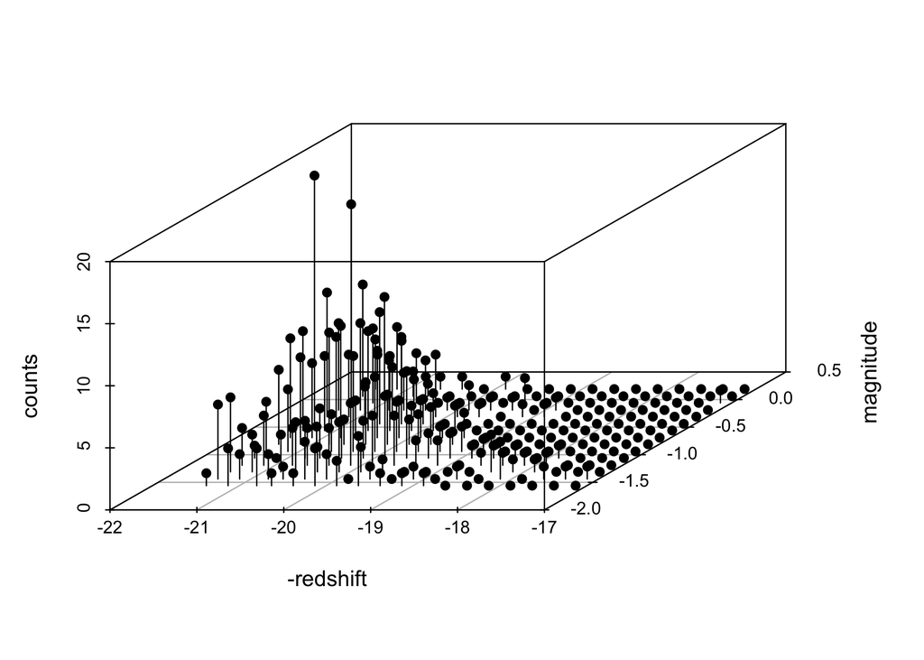

```r
library("scatterplot3d")

load('./galaxy.RData')
scatterplot3d(x = -galaxy_df$redshifts,
              y = galaxy_df$magnitudes,
              z = galaxy_df$counts, pch = 16, type="h",
              xlab = '-redshift',
              ylab = 'magnitude',
              zlab = 'counts')
```

This count data allows to visualize the joint distribution of redshifts and magnitudes. For example, most galaxies in this dataset have large redshifts and small magnitudes.

Suppose we wanted to smooth the counts in this dataset. We propose to do a Poisson regression, where $y_i$ is the number of galaxies in each bin, and we model the mean $\lambda_i$ of each bin as

$$\lambda_i = \exp(\beta_0 + \beta_1 \cdot \text{redshift} + \beta_2 \cdot \text{magnitude} + \beta_3 \cdot \text{redshift} \cdot \text{magnitude} +
\beta_4 \cdot \text{magnitude}^2 + \beta_5 \cdot \text{redshift}^2 )$$
and then

$$y_i \sim \text{Poisson}(\lambda_i)$$
.

We run the Poisson regression:

```r
# run poisson regression
galaxy_df$redshift2 <- galaxy_df$redshifts**2
galaxy_df$magnitude2 <- galaxy_df$magnitudes**2
galaxy_df$redshifts_magnitudes <- galaxy_df$redshifts * galaxy_df$magnitudes


poisson_glm <- glm(counts ~ ., data = galaxy_df,
                   family = poisson())

summary(poisson_glm)
```

```
##
## Call:
## glm(formula = counts ~ ., family = poisson(), data = galaxy_df)
##
## Deviance Residuals:
##     Min       1Q   Median       3Q      Max
## -3.1539  -0.6621  -0.2485   0.1750   3.6570
##
## Coefficients:
##                        Estimate Std. Error z value Pr(>|z|)
## (Intercept)          -135.08743   24.66985  -5.476 4.36e-08 ***
## redshifts              11.43154    2.38009   4.803 1.56e-06 ***
## magnitudes            -28.12539    3.33712  -8.428  < 2e-16 ***
## redshift2              -0.23448    0.05756  -4.073 4.63e-05 ***
## magnitude2             -1.51699    0.21533  -7.045 1.86e-12 ***
## redshifts_magnitudes    1.26237    0.15549   8.118 4.72e-16 ***
## ---
## Signif. codes:  0 '***' 0.001 '**' 0.01 '*' 0.05 '.' 0.1 ' ' 1
##
## (Dispersion parameter for poisson family taken to be 1)
##
##     Null deviance: 903.68  on 269  degrees of freedom
## Residual deviance: 229.11  on 264  degrees of freedom
## AIC: 646.14
##
## Number of Fisher Scoring iterations: 6
```

And we plot the $\lambda_i$ against the magnitude and redshifts.

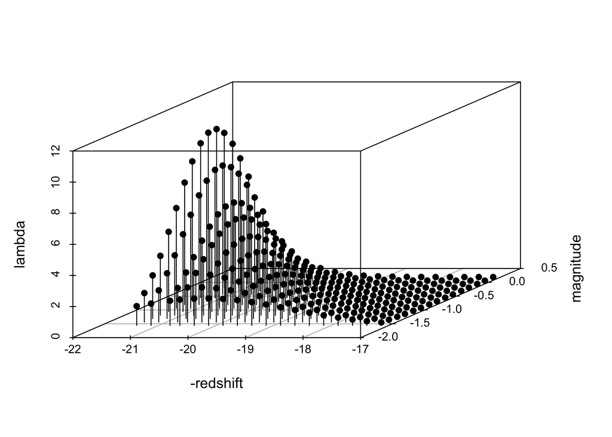

```r
poisson_preds <- predict(poisson_glm, newdata = galaxy_df,
                        type = 'response')

scatterplot3d(x = -galaxy_df$redshifts,
              y = galaxy_df$magnitudes,
              z = poisson_preds, pch = 16, type="h",
              xlab = '-redshift',
              ylab = 'magnitude',
              zlab = 'lambda')
```

We now have a smoothed distribution of counts fit using Poisson regression.

[^1]: https://archive.ics.uci.edu/ml/datasets/spambase
[^2]: galaxy data from https://web.stanford.edu/~hastie/CASI/index.html, table 8.5